# **Trends in the Streetwear Aftermarket**

By Michael Weinberger and Benyam Ephrem

CMSC320 - Fall 2019

[figure not shown]

## **Overview**

The sneaker & streetwear reselling market is a [near 2 billion dollar industry](https://www.npr.org/2017/11/26/556090186/is-the-streetwear-market-headed-for-the-mainstream), expecting to triple in the next 5 years.

Individuals spend thousands of dollars a year on pieces of software, private information groups, and more to help secure these sought after items in order to resell for profit, sometimes at even 500% of their original retail price.

#### **How Does This Work?**

[figure not shown]

Retailers create [artificial scarcity](https://en.wikipedia.org/wiki/Artificial_scarcity) for the products in an effort to increase the hype and desire for them. This augmented desire and demand leads to higher prices, more publicity, and subsequently maximal profit.

There are **3 key interactors** in this system:

##### 1. Suppliers

##### 2. Resellers

##### 3. End Consumers

Let's look at each of these in more depth.

#### **Suppliers**

[figure not shown]

Suppliers are the **original makers** of a streetwear product. They define authenticity, drive branding, and decide supply of their products.

For most products with reputable brands in this space (i.e. [Yeezy](https://www.yeezysupply.com/), [Supreme](https://www.supremenewyork.com/)), the more limited an item is, the more desirable it is.

This leads to a mutual benefit: suppliers profit from selling to resellers, resellers profit from low stock and high demand (due to hype), and end consumers get a scarce product that is now more valuable to possess.

So although an original supplier could sell at the end consumer price, it is more beneficial to the brand to create the artifical scarcity and sell at a (still high and very profitable) retail price.

#### **Resellers**

[figure not shown]

Resellers use special software like bots (i.e. [AIObot](https://www.aiobot.com/), [Prism](https://www.prismaio.com/)) to purchase sneakers after they "drop" (release). Often, a normal person cannot buy the most sought after streetwear themselves with a normal web client (browsing to the site and checking out).

Bots that the resellers operate will buy up all of the inventory as soon as the sneakers are open for purchase and supply sells out in seconds.

#### **End Consumers**

[figure not shown]

These are the final consumers who purchase the items in the aftermarket. Sites like [StockX](https://stockx.com/) (which we will be scraping our data from for analysis) give these consumers a place to purchase these items.

StockX strives to be a transparent market where consumers can see extensive final resale prices for the products that they want to buy. People can make bids, place immediate buys, or become a seller themselves.

#### **Why It All Works**

At each level of product exchange, the prices get higher and profits are consistently made.

The key fact that makes it all come together is that **each level gets more value, not less**.

## **Our Investigation & Analysis**

[figure not shown]

With such an incredibly interesting micro-economy and marketplace, there exist fascinating trends that we can analyze to better understand how buyers & sellers are interacting.

We decided to look at 3 popular brands, **[Nike](https://www.nike.com/)**, **[Supreme](https://www.supremenewyork.com/)**, and **[Kith](https://kith.com/)**.

For each brand we will ask what features of a product (category, color, retail price, etc.) best correlate with resale price.

In other words, can we use these predictors to recommend to each of these brands what future products they should work on to maximize hype and resale price.

We will be sourcing our data from [StockX](https://stockx.com/) given that it is the largest online marketplace for buying and selling sneakers & streetware.

StockX offers a [public API](https://github.com/stockx/PublicAPI), but we will be directly consuming the API that their web client consumes by reproducing requests ourselves.

## **Data Collection**

The first step in the process is to collect all of the data that we need. To do this, we will be scraping StockX.

While StockX does have a public facing API with documentation, it is relatively weak and unsupported. We had to find a way to get data on thousands of products all at once. To do this, we sniffed the requests being made by the browser via the Chrome network tab when you search for a product on the StockX.

We duplicated the headers and URL and luckily, StockX presented us with very robust and exhaustive data on all of the returned products.

[figure not shown]

Something we unfortunately realized is that StockX will only return you a maximum of 1000 products, no matter what the search query is. To somewhat remedy this, we decided to add filters and perform multiple searches. So, instead of searching all categories for Nike, Kith, and Supreme, we searched an array of categories for each one and concatenated the results. This gave us around 1,500 products for each brand.

Another issue we ran into is that because we are not using the supported public endpoints, the StockX API will rate limit your IP if you try to query it too much. In order to get around this, we made use of around 100 proxies that we randomly rotated through to bypass this security measure. With this, we were able to successfully query the StockX API and scrape the data we needed.

```python
'''
Define Imports
'''

import seaborn as sns
import random
import datetime
import requests
import pandas as pd
import numpy as np
import matplotlib.pyplot as plt
import matplotlib.dates as mdates
import matplotlib.colors as clrs

from sklearn.linear_model import Ridge
from sklearn.preprocessing import PolynomialFeatures
from sklearn.pipeline import make_pipeline
from sklearn.svm import SVR
from sklearn.linear_model import LinearRegression
from sklearn.model_selection import train_test_split

pd.set_option('display.max_columns', None)
```

```python
'''
Scrape Data
'''

stockx_api = 'https://stockx.com/api'
stockx_headers = {
  'authority': 'stockx.com',
  'method': 'GET',
  'path': '/api/browse?&_search=nike&dataType=product&country=US',
  'scheme': 'https',
  'accept': '*/*',
  'accept-encoding': 'gzip, deflate, br',
  'accept-language': 'en-US,en;q=0.9,he;q=0.8,ms;q=0.7,la;q=0.6',
  'appos': 'web',
  'appversion': '0.1',
  'authorization': '',
  'cache-control': 'no-cache',
  'pragma': 'no-cache',
  'referer': 'https://stockx.com/search?s=nike',
  'sec-fetch-mode': 'cors',
  'sec-fetch-site': 'same-origin',
  'user-agent': 'Mozilla/5.0 (Macintosh; Intel Mac OS X 10_15_0) AppleWebKit/537.36 (KHTML, like Gecko) Chrome/78.0.3904.108 Safari/537.36',
  'x-anonymous-id': 'undefined',
  'x-requested-with': 'XMLHttpRequest'
}

# list of proxies so StockX doesn't ban us (modified for security reasons)
proxies = [
'127.0.0.1:8476:example:example',
'127.0.0.1:24799:example:example',
'127.0.0.1:23111:example:example',
'127.0.0.1:27533:example:example',
'127.0.0.1:33430:example:example',
'127.0.0.1:10562:example:example',
'127.0.0.1:20349:example:example',
'127.0.0.1:50047:example:example',
'127.0.0.1:10750:example:example',
'127.0.0.1:37764:example:example',
'127.0.0.1:51994:example:example',
'127.0.0.1:12737:example:example',
'127.0.0.1:47355:example:example',
'127.0.0.1:16468:example:example',
'127.0.0.1:50897:example:example',
'127.0.0.1:14619:example:example',
'127.0.0.1:52408:example:example',
'127.0.0.1:35446:example:example',
'127.0.0.1:13290:example:example',
'127.0.0.1:9742:example:example',
'127.0.0.1:46078:example:example',
'127.0.0.1:31814:example:example',
'127.0.0.1:32802:example:example',
'127.0.0.1:59824:example:example',
'127.0.0.1:21521:example:example',
'127.0.0.1:48056:example:example',
'127.0.0.1:25511:example:example',
'127.0.0.1:56715:example:example',
'127.0.0.1:38258:example:example',
'127.0.0.1:51766:example:example',
'127.0.0.1:47127:example:example',
'127.0.0.1:27758:example:example',
'127.0.0.1:28287:example:example',
'127.0.0.1:12600:example:example',
'127.0.0.1:24371:example:example',
'127.0.0.1:3128:example:example',
'127.0.0.1:3128:example:example',
'127.0.0.1:3128:example:example',
'127.0.0.1:3128:example:example',
'127.0.0.1:3128:example:example',
'127.0.0.1:3128:example:example',
'127.0.0.1:3128:example:example',
'127.0.0.1:3128:example:example',
'127.0.0.1:3128:example:example',
'127.0.0.1:3128:example:example',
'127.0.0.1:3128:example:example',
'127.0.0.1:3128:example:example',
'127.0.0.1:3128:example:example',
'127.0.0.1:3128:example:example',
'127.0.0.1:3128:example:example',
'127.0.0.1:3128:example:example',
'127.0.0.1:3128:example:example',
'127.0.0.1:3128:example:example',
'127.0.0.1:3128:example:example',
'127.0.0.1:3128:example:example',
'127.0.0.1:3128:example:example',
'127.0.0.1:3128:example:example',
'127.0.0.1:3128:example:example',
'127.0.0.1:3128:example:example',
'127.0.0.1:3128:example:example',
'127.0.0.1:3128:example:example',
'127.0.0.1:3128:example:example',
'127.0.0.1:3128:example:example',
'127.0.0.1:3128:example:example',
'127.0.0.1:3128:example:example',
'127.0.0.1:3128:example:example',
'127.0.0.1:3128:example:example',
'127.0.0.1:3128:example:example',
'127.0.0.1:3128:example:example',
'127.0.0.1:3128:example:example',
'127.0.0.1:3128:example:example',
'127.0.0.1:3128:example:example',
'127.0.0.1:3128:example:example',
'127.0.0.1:3128:example:example',
'127.0.0.1:3128:example:example',
'127.0.0.1:3128:example:example',
'127.0.0.1:3128:example:example',
'127.0.0.1:3128:example:example',
'127.0.0.1:3128:example:example',
'127.0.0.1:3128:example:example',
'127.0.0.1:3128:example:example',
'127.0.0.1:3128:example:example',
'127.0.0.1:3128:example:example',
'127.0.0.1:3128:example:example',
'127.0.0.1:3128:example:example',
'127.0.0.1:3128:example:example',
'127.0.0.1:3128:example:example',
'127.0.0.1:3128:example:example',
'127.0.0.1:3128:example:example',
'127.0.0.1:3128:example:example',
'127.0.0.1:3128:example:example',
'127.0.0.1:3128:example:example',
'127.0.0.1:3128:example:example',
'127.0.0.1:3128:example:example',
'127.0.0.1:3128:example:example',
'127.0.0.1:3128:example:example',
'127.0.0.1:3128:example:example',
'127.0.0.1:3128:example:example',
'127.0.0.1:3128:example:example',
'127.0.0.1:3128:example:example',
'127.0.0.1:3128:example:example',
'127.0.0.1:3128:example:example',
'127.0.0.1:3128:example:example',
'127.0.0.1:3128:example:example',
'127.0.0.1:3128:example:example',
'127.0.0.1:3128:example:example',
'127.0.0.1:3128:example:example',
'127.0.0.1:3128:example:example',
'127.0.0.1:3128:example:example',
'127.0.0.1:3128:example:example',
'127.0.0.1:3128:example:example',
'127.0.0.1:3128:example:example',
'127.0.0.1:3128:example:example',
'127.0.0.1:3128:example:example',
'127.0.0.1:3128:example:example',
'127.0.0.1:3128:example:example',
'127.0.0.1:3128:example:example',
'127.0.0.1:3128:example:example',
'127.0.0.1:3128:example:example',
'127.0.0.1:3128:example:example',
'127.0.0.1:3128:example:example',
'127.0.0.1:3128:example:example',
'127.0.0.1:3128:example:example',
'127.0.0.1:3128:example:example',
'127.0.0.1:3128:example:example',
'127.0.0.1:3128:example:example',
'127.0.0.1:3128:example:example',
'127.0.0.1:3128:example:example',
'127.0.0.1:3128:example:example',
'127.0.0.1:3128:example:example',
'127.0.0.1:3128:example:example',
'127.0.0.1:3128:example:example',
'127.0.0.1:3128:example:example',
'127.0.0.1:3128:example:example',
'127.0.0.1:3128:example:example',
'127.0.0.1:3128:example:example',
'127.0.0.1:3128:example:example',
'127.0.0.1:3128:example:example',
'127.0.0.1:3128:example:example',
'127.0.0.1:3128:example:example',
'127.0.0.1:3128:example:example',
'127.0.0.1:3128:example:example',
'127.0.0.1:3128:example:example',
'127.0.0.1:3128:example:example',
'127.0.0.1:3128:example:example',
'127.0.0.1:3128:example:example',
'127.0.0.1:3128:example:example',
'127.0.0.1:3128:example:example',
'127.0.0.1:3128:example:example',
'127.0.0.1:3128:example:example',
'127.0.0.1:3128:example:example',
'127.0.0.1:3128:example:example',
'127.0.0.1:3128:example:example',
'127.0.0.1:3128:example:example',
'127.0.0.1:3128:example:example',
'127.0.0.1:3128:example:example',
'127.0.0.1:3128:example:example'
]

# list of brands to query
brands = ['nike', 'kith', 'supreme']
categories = ['sneakers', 'streetwear', 'collectibles']

# raw data dictionary to be used later
raw_data = {}

'''
Utility function to get
a random proxy for our query
'''
def get_random_proxy():
  raw_proxy_index = random.randint(0, len(proxies) - 1)
  raw_proxy = proxies[raw_proxy_index]
  raw_proxy_fields = raw_proxy.split(':')

  proxy = f'{raw_proxy_fields[2]}:{raw_proxy_fields[3]}@{raw_proxy_fields[0]}:{raw_proxy_fields[1]}'
  proxy_dict = {"http": f'http://{proxy}', "https": f'https://{proxy}'}

  return proxy_dict

'''
Get number of pages for a given
search query via StockX website
'''
def get_num_pages(brand, category):
  response = requests.get(
      f'{stockx_api}/browse?productCategory={category}&sort=most-active&_search={brand}&dataType=product&country=US',
      headers=stockx_headers,
      proxies=get_random_proxy()
  )

  if response.status_code != 200:
    raise Exception('Blocked by StockX')

  body = response.json()
  pagination = body['Pagination']
  last_page_url = pagination['lastPage']
  last_page_index = last_page_url.index('page=')
  last_page = int(last_page_url[last_page_index + 5:])

  return last_page

'''
Get product data given a page
and a search query (a brand in our case)
'''
def get_products(brand, category, page):
  response = requests.get(
      f'{stockx_api}/browse?productCategory={category}&sort=most-active&_search={brand}&dataType=product&country=US&page={page}',
      headers=stockx_headers,
      proxies=get_random_proxy()
  )

  if response.status_code != 200:
    raise Exception('Blocked by StockX')

  body = response.json()
  products = body['Products']

  return products

'''
Main function to concatenate products
queried for each page for each brand
and store in our raw_data map
'''
def get_brand_data(brand):
  products = []

  for category in categories:
    num_pages = get_num_pages(brand, category)

    for page in range(num_pages):
      products += get_products(brand, category, page)

  raw_data[brand] = products

for brand in brands:
  get_brand_data(brand)
```

## **Data Processing**

The StockX API returns their responses in JSON, which makes it relatively easy for us to do some basic cleaning and load it into a Pandas DataFrame.

However, there was a nested JSON object in the response that we had to manually pull values from. Another big issue we had to deal with was the color of each product. Each product on StockX has a colorway, which is the variant of the product. This colorway is not necessarily a normal color, like black, but could be something like "dark obsidian." To remedy this, we created a mapping from unknown colorway to a known color by manually looking at each product (there was only around 50 unknown colorways that we had to manually map).

```python
'''
Organize and Prune Data
'''

nike_products = raw_data['nike']
kith_products = raw_data['kith']
supreme_products = raw_data['supreme']

'''
Utility function to grab the market
object field and tack on the values
we care about
'''
def add_market_data(row):
  market_data = row['market']

  row['totalDollars'] = market_data['totalDollars']
  row['salesThisPeriod'] = market_data['salesThisPeriod']
  row['annualHigh'] = market_data['annualHigh']
  row['annualLow'] = market_data['annualLow']
  row['lowestAsk'] = market_data['lowestAsk']
  row['averageDeadstockPrice'] = market_data['averageDeadstockPrice']

  # Retail Premium
  if row['averageDeadstockPrice'] is not None:
    diff = row['averageDeadstockPrice'] - row['retailPrice']
    row['percent_over_retail'] = diff / row['retailPrice']

  return row

colors = [
  'black', 'white', 'blue', 'red', 'gold', 'orange',
  'navy', 'yellow', 'gray', 'silver',
  'purple', 'green', 'brown', 'pink'
]

unknown_color_mapping = {
  'olive': 'green',
  'camo': 'green',
  'khaki': 'brown',
  'tan': 'brown',
  'burgundy': 'red',
  'teal': 'green',
  'beige': 'white',
  'viotech/viotech': 'white',
  'multi': 'black',
  'frosted spruce/aluminum': 'green',
  'desert ore/desert ore-hyper jade-bright mango': 'tan',
  'monarch/sail-amarillo': 'orange',
  'dusty peach/dusty peach': 'orange',
  'obsidian/obsidian-obsidian-obsidian': 'navy',
  'muslin/muslin-desert ore': 'tan',
  'cream/sail-light bone': 'white',
  'game royal/game royal': 'black',
  'vintage lichen/dark russet-light bone': 'silver',
  'barely rose/barely rose': 'white',
  'muted bronze/burnt sienna-sail': 'orange',
  'light bone/bone': 'white',
  'jade horizon/sequoia': 'gray',
  'grey': 'gray',
  'moon particle/ridgerock-sepia stone-bright crimson-sail': 'tan',
  'moon particle/bright crimson-sepia stone': 'tan',
  'frosted spruce/frosted spruce-frosted spruce': 'green',
  'dark stucco/sandtrap-flat zinc': 'green',
  'frosted spruce': 'green',
  'dust/sail': 'pink',
  'string/kumquat/off noir': 'orange',
  'denim': 'blue',
  'dark obsidian': 'black',
  'mars stone': 'orange',
  'wild mango': 'orange',
  'snakeskin': 'silver',
  'vanilla': 'white',
  'jade': 'green',
  'clay': 'orange',
  'crushed granite': 'gray',
  'phantom': 'black',
  'slate': 'gray',
  'midnight turqoise': 'green',
  'dual tone concrete slab': 'gray',
  'onyx': 'black',
  'off noir': 'black',
  'game royal': 'black',
  'light bone': 'white',
  'sequoia/obsidian': 'green',
  'dark magenta': 'purple',
  'volt': 'green',
  'pastel': 'panel',
  'cyber/game royal': 'green',
  'cyber': 'green',
  'bleached coral': 'white',
  'mustard': 'yellow',''
  'kumquat': 'orange',
  'bright ceramic': 'white',
  'black/egret-black': 'black'
}

def extract_color(row):
  raw_colorway = row['colorway'] if row['colorway'] else 'black'
  colorway = raw_colorway.lower()
  extracted_color = None

  for color in colors:
    if color in colorway:
      extracted_color = color
      break

  if colorway in unknown_color_mapping and extracted_color is not None:
    extracted_color = unknown_color_mapping[colorway]

  extracted_color = extracted_color if extracted_color is not None else 'black'

  row['color'] = extracted_color

  return row


'''
Utility function to take in array of product
data scraped from StockX, load into a dataframe,
and grab our desired values
'''
def prune_brand_data(raw_brand_data):
  # Create dataframe
  df_raw = pd.DataFrame(raw_brand_data)

  # Convert type of retailPrice
  df_raw['retailPrice'] = pd.to_numeric(df_raw['retailPrice'])

  # Populate nested market data
  df_raw = df_raw.apply(lambda row: add_market_data(row), axis=1)

  # Grab the columns that we will be working with
  df = df_raw[[
    'category', 'colorway', 'gender', 'productCategory',
    'releaseDate', 'retailPrice', 'totalDollars', 'salesThisPeriod',
    'annualHigh', 'annualLow', 'lowestAsk', 'averageDeadstockPrice', 'percent_over_retail', '_tags']]

  # Extract color
  df = df.apply(lambda row: extract_color(row), axis=1)

  # Filter critical fields for empty states
  df = df.replace(to_replace='None', value=np.nan)
  df = df[df['retailPrice'].notnull()]
  df = df[df['averageDeadstockPrice'].notnull()]
  df = df[df['percent_over_retail'].notnull()]

  return df

nike_df = prune_brand_data(nike_products)
kith_df = prune_brand_data(kith_products)
supreme_df = prune_brand_data(supreme_products)

nike_df.head()
```

|  | category | colorway | gender | productCategory | releaseDate | retailPrice | totalDollars | salesThisPeriod | annualHigh | annualLow | lowestAsk | averageDeadstockPrice | percent_over_retail | _tags | color |
| --- | --- | --- | --- | --- | --- | --- | --- | --- | --- | --- | --- | --- | --- | --- | --- |
| 0 | Nike Basketball Dunk | Viotech/Viotech | men | sneakers | 2019-12-10 23:59:59 | 120.0 | 364802.0 | 493.0 | 387.0 | 150.0 | 155.0 | 188.0 | 0.566667 | [sneakers, nike, nike basketball, dunk, retail... | black |
| 1 | Air Force One | White/White | men | sneakers | 2018-01-01 23:59:59 | 90.0 | 1183331.0 | 491.0 | 245.0 | 40.0 | 78.0 | 85.0 | -0.055556 | [sneakers, nike, air force, one, style_id\|3151... | white |
| 2 | Converse | Black/Egret-Black | men | sneakers | 2019-04-18 23:59:59 | 140.0 | 920441.0 | 414.0 | 750.0 | 130.0 | 150.0 | 248.0 | 0.771429 | [sneakers, converse, other brands, converse, r... | black |
| 3 | Air Force One | White/White | women | sneakers | 2018-01-01 23:59:59 | 90.0 | 234432.0 | 338.0 | 180.0 | 60.0 | 98.0 | 108.0 | 0.200000 | [sneakers, nike, air force, one, style_id\|3151... | white |
| 4 | Air Force One | Black/Anthracite | men | sneakers | 2019-12-07 23:59:59 | 180.0 | 279689.0 | 271.0 | 709.0 | 200.0 | 224.0 | 358.0 | 0.988889 | [sneakers, nike, air force, one, style_id\|ct66... | black |

## **Exploratory Analysis**

After processing and preparing the data, the first thing we wanted to do was to generally analyze it.

### **Investigating Average Resale Profits**

What are the average resell profits for each of the brands?

```python
'''
Exploratory Analysis
'''

# Compute the average resell margin for the brands

def compute_average_resell_margin(brand):
  if brand == 'nike':
    df = nike_df
  elif brand == 'kith':
    df = kith_df
  else:
    df = supreme_df

  df['resell_margin'] = df.apply(
      lambda row: float(row['averageDeadstockPrice']) - float(row['retailPrice']),
      axis=1
  )
  df['resell_margin_total'] = df.apply(
      lambda row: float(row['resell_margin']) * float(row['salesThisPeriod']),
      axis=1
  )

  total_margins = df["resell_margin_total"].sum()
  num_sales = df["salesThisPeriod"].sum()

  return round(total_margins / num_sales, 2)

for brand in brands:
  print(f'{brand} average resale profit ${compute_average_resell_margin(brand)}')
```

```
nike average resale profit $54.48
kith average resale profit $42.0
supreme average resale profit $181.97
```

```python
supreme_df.head()
```

|  | category | colorway | gender | productCategory | releaseDate | retailPrice | totalDollars | salesThisPeriod | annualHigh | annualLow | lowestAsk | averageDeadstockPrice | percent_over_retail | _tags | color | resell_margin | resell_margin_total |
| --- | --- | --- | --- | --- | --- | --- | --- | --- | --- | --- | --- | --- | --- | --- | --- | --- | --- |
| 0 | Nike SB SB Dunk Low | Metallic Silver/Metallic Silver-Black | men | sneakers | 2019-09-14 23:59:59 | 110.0 | 1718408.0 | 29.0 | 700.0 | 130.0 | 145.0 | 311.0 | 1.827273 | [sneakers, nike, nike sb, sb dunk low, style_i... | black | 201.0 | 5829.0 |
| 1 | Nike SB SB Dunk Low | Metallic Gold/Metallic Gold-Midnight Navy-White | men | sneakers | 2019-09-14 23:59:59 | 110.0 | 785972.0 | 28.0 | 480.0 | 109.0 | 130.0 | 248.0 | 1.254545 | [sneakers, nike, nike sb, sb dunk low, style_i... | white | 138.0 | 3864.0 |
| 2 | Nike SB SB Dunk Low | Varsity Red/Varsity Red-White-Black | men | sneakers | 2019-09-14 23:59:59 | 110.0 | 1747490.0 | 28.0 | 700.0 | 123.0 | NaN | 333.0 | 2.027273 | [sneakers, nike, nike sb, sb dunk low, style_i... | black | 223.0 | 6244.0 |
| 3 | Nike SB Other | Black/White-Spirit Teal-Gum Light Brown | men | sneakers | 2018-08-30 23:59:59 | 110.0 | 95993.0 | 12.0 | 210.0 | 60.0 | 116.0 | 127.0 | 0.154545 | [sneakers, nike, nike sb, other, style_id\|ar98... | black | 17.0 | 204.0 |
| 4 | Air Max Other | White/University Red-White-Geyser Grey | men | sneakers | 2019-03-21 23:59:59 | 190.0 | 415692.0 | 10.0 | 425.0 | 90.0 | 195.0 | 215.0 | 0.131579 | [sneakers, nike, air max, other, style_id\|at38... | white | 25.0 | 250.0 |

What we found was pretty expected, with Supreme having the most resell margins of ≈ \$181.97, Nike coming in 2nd with ≈ \$54.48, and then Kith coming in last with ≈ \$42.00.

Something that is important to note, though, is that the data we are using may be a bit biased. The data is pre-sorted by StockX based on a product's sales from the past 72 hours.

If we were to collect all the data that StockX has to offer for each of these companies we would need thousands of proxies (in order to perform the thousands of queries required).

Nevertheless, with this restriction if we were to choose a subset of products to analyze, we would want to analyze the hottest sellers as these are the most important products for us to look at to provide Nike, Supreme, & Kith recommendations to maximize reseller profit.

### **Exploring Resale Margins Per Category**

Next, it may be interesting to see the sales performance of each category on a brand by brand basis.

Let's investigate that now:

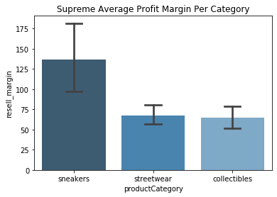

```python
sns.barplot(x='productCategory', y='resell_margin', data=supreme_df, capsize=.2, palette="Blues_d").set_title('Supreme Average Profit Margin Per Category')
```

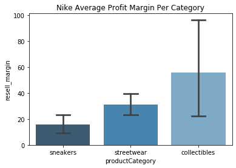

```python
sns.barplot(x='productCategory', y='resell_margin', data=nike_df, capsize=.2, palette="Blues_d").set_title('Nike Average Profit Margin Per Category')
```

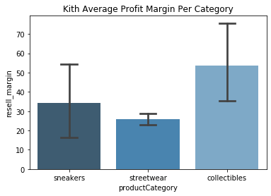

```python
sns.barplot(x='productCategory', y='resell_margin', data=kith_df, capsize=.2, palette="Blues_d").set_title('Kith Average Profit Margin Per Category')
```

**These are interesting results.**

Let's consider what we initially thought would happen. Nike is best known for its sneakers, Supreme and Kith are best known for their streetwear.

However, looking at the results from these bar charts we see that the products that had the highest average profit margins were sneakers for Supreme, collectibles for Nike (which is very surprising), and collectibles for Kith. This is less surprising for Kith as they are known for making collectibles in addition to streetwear.

**What these graphs don't show is the volume of sales for each category.**

For example, Nike could sell one collectible that does really well (in terms of resale margin), but it could have very low volume. On the other hand, sneakers are very high volume. This means that there will be many more average sneakers versus very rare collectibles.

This does not mean that Nike should solely (pun intended) sell collectibles because their extreme rareness is what gives them such a high profit margin.

Let's look at an example, the [Bearbrick Nike SB 1000% White](https://stockx.com/bearbrick-nike-sb-1000-white):

[figure not shown]

Notice the retail is \$375 and the last sale stands at \$710 (a resale profit of \$335). This product averages 89.3% over retail price. If we look at a shoe like the [Jordan 1 Retro's](https://stockx.com/air-jordan-1-retro-high-fearless-unc-chicago) we observe a much lower price premium of 25% over retail (although to make this a conclusive observation we'd want to look at all products price premiums per category).

When we look at the volume it becomes a bit more clear what is going on.

For the Bearbrick's we see:

[figure not shown]

Interesting, and the Jordan 1 Retro's?

[figure not shown]

And this makes sense, the Jordan's have thinner margins, but the sales volume is massive compared to any of the rare collectibles.

### **Diving Deeper With Category Sales Volume**

So the natural thing to do next is to look at the total sales volume for each category. In the last section we say that better margins only tell a part of the picture.

Let's look deeper to see if we can make more sense of our data:

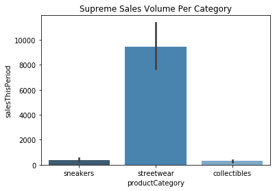

```python
sns.barplot(x='productCategory', y='salesThisPeriod', data=supreme_df, estimator=sum, palette="Blues_d").set_title('Supreme Sales Volume Per Category')
```

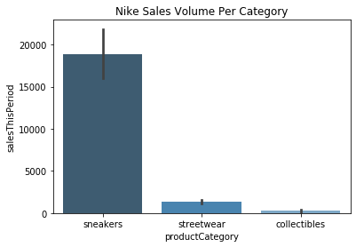

```python
sns.barplot(x='productCategory', y='salesThisPeriod', data=nike_df, estimator=sum, palette="Blues_d").set_title('Nike Sales Volume Per Category')
```

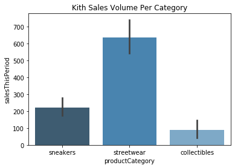

```python
sns.barplot(x='productCategory', y='salesThisPeriod', data=kith_df, estimator=sum, palette="Blues_d").set_title('Kith Sales Volume Per Category')
```

**Now things are making sense.** The sales volume for each category is what we expected, with Supreme's highest volume coming from streetwear, Nike's highest volume coming from sneakers, and Kith's coming from streetwear.

### **Sales Volume and Resale Margin**

Now that we have a clearer understanding of how sales volume is affecting a category's profit margins, can we identify a relationship between those variables specifically?

In other words, how does sales volume affect resale margin?

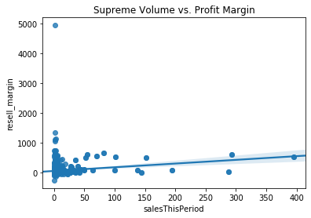

```python
sns.regplot(x='salesThisPeriod', y='resell_margin', data=supreme_df).set_title('Supreme Volume vs. Profit Margin')
```

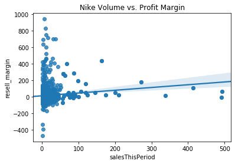

```python
sns.regplot(x='salesThisPeriod', y='resell_margin', data=nike_df).set_title('Nike Volume vs. Profit Margin')
```

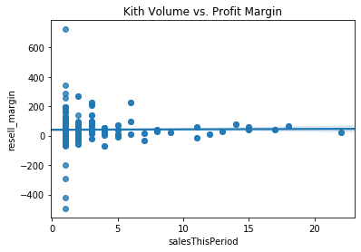

```python
sns.regplot(x='salesThisPeriod', y='resell_margin', data=kith_df).set_title('Kith Volume vs. Profit Margin')
```

So can we draw any conclusions from this? It seems clear that most of the data points are bunched up and the outliers may be what are "tilting" the regression line making it "kind of" work.

Let's see if we have outliers in with respect to sales volume distributions:

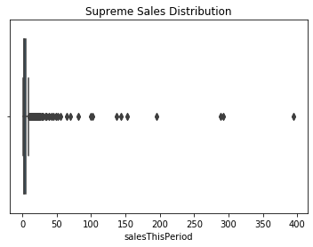

```python
sns.boxplot(x=supreme_df["salesThisPeriod"]).set_title('Supreme Sales Distribution')
```

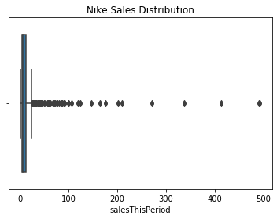

```python
sns.boxplot(x=nike_df["salesThisPeriod"]).set_title('Nike Sales Distribution')
```

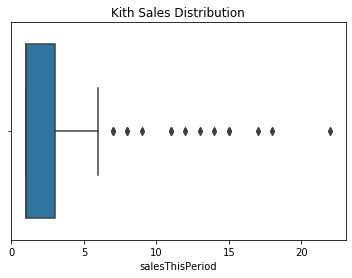

```python
sns.boxplot(x=kith_df["salesThisPeriod"]).set_title('Kith Sales Distribution')
```

We see that the Supreme and Nike sales distribution are dominated by outliers. Let's see if we can cut those out to have a closer look at the sales volume vs. resale margin.

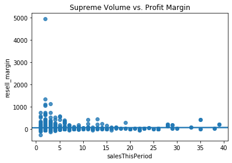

```python
sns.regplot(x='salesThisPeriod', y='resell_margin', data=supreme_df[supreme_df['salesThisPeriod'] < 40]).set_title('Supreme Volume vs. Profit Margin')
```

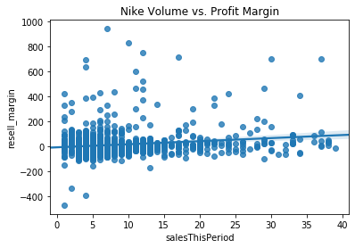

```python
sns.regplot(x='salesThisPeriod', y='resell_margin', data=nike_df[nike_df['salesThisPeriod'] < 40]).set_title('Nike Volume vs. Profit Margin')
```

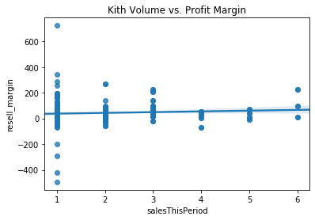

```python
sns.regplot(x='salesThisPeriod', y='resell_margin', data=kith_df[kith_df['salesThisPeriod'] < 7]).set_title('Kith Volume vs. Profit Margin')
```

This still looks inconclusive. For each company, there are items with very low sales volume that carry high resale margins (which makes sense, the hype and scarcity boosts profits), but there are are also high sales volume products with high margins as well (equivalent to that of low sales volume products).

Though, it seems that **there is a higher concentration of high margin products with few sales**. This reinforces that scarcity may increase resale margin. All things for us to consider as we move forward.

### **Exploring Item Color & Demographic**

[figure not shown]

Next, we will look at item color and see how it impacts resale margin as well as sales volume. [Color psychology](https://en.wikipedia.org/wiki/Color_psychology) is an important facet of retail sales as well as inventory placement.

```python
def category_color_resale_heatmap(df, company):
  plt.figure(figsize=(20,10))
  df_pivoted = df.pivot_table(index='productCategory', columns='color', values="resell_margin", aggfunc=np.mean)
  sns.heatmap(df_pivoted, annot=True, fmt=".1f", cmap="YlGnBu").set_title(f'{company} Resale Margin Per Category-Color Combo')
```

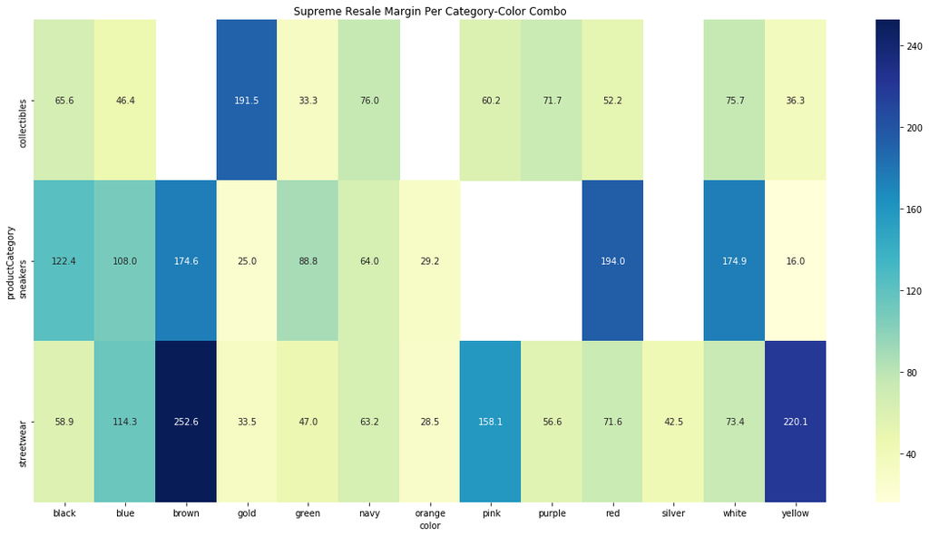

```python
category_color_resale_heatmap(supreme_df, "Supreme")
```

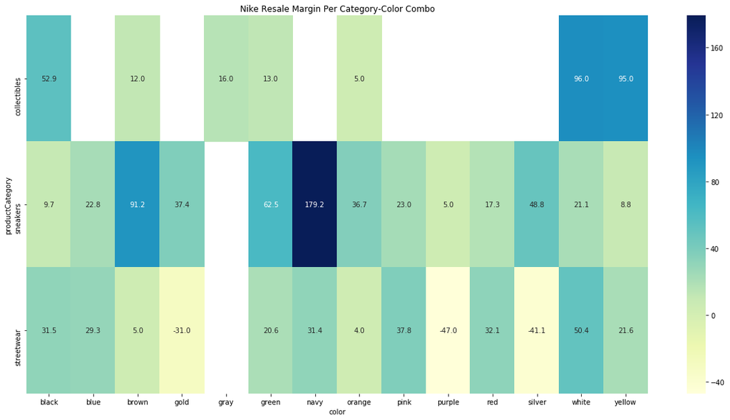

```python
category_color_resale_heatmap(nike_df, "Nike")
```

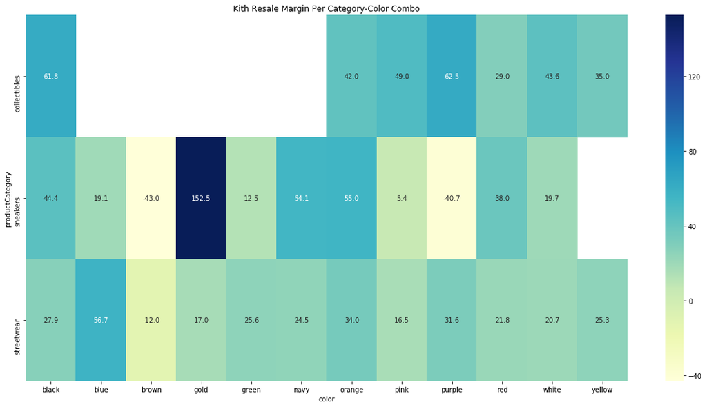

```python
category_color_resale_heatmap(kith_df, "Kith")
```

So this is interesting, these heatmaps show us something that might have been subtle before. **Products can have margins below 0, a loss.**

This can happen when a product is over-hyped and the release does not go well. Or, the product may just not be that desirable and it is no longer a good item to even bring to the resale market if you bought it at retail (you will lose money trying to resell it, but may be fine if you want to cut your losses short on massive inventory).

Let's look company by company, category by category.

###### **Supreme**

We saw before that Supreme boasts the highest resale margins over Nike and Kith. Thier highest volume category was Streetwear.

We notice that their highest margin products also reside in the streetwear category, with brown, pink, and yellow toned products seeing high margins.

###### **Nike**

Nike's highest volume category was sneakers. We see that Navy sneakers reap the highest margins. But the mean resale margin for Navy sneakers seems a bit high, we need to be cautious of outliers here. We will take note of this as we continue.

We also see that Nike does not offer collectibles in that many colors which makes sense as Nike has very low relative sales volume coming from their collectibles.

###### **Kith**

Next, Kith has a wide variety of colors performing evenly well in streetwear. In sneakers, Gold and multi-color sneakers have high relative margins.

Again, we should be wary of outliers and "one-off" products skewing the data. In collectibles we see solid resale margins hovering around \$40, above that of the streetwear which sits around \$25.

### **Demographic Performance Per Category**

We just looked at how color influences resale margin in each category, let's see how demographic influences these figures.

First we will look at sales volume in each category for each demographic, then we will look at resale margin per demographic per category.

#### **Sales Volume & Demographic**

```python
def category_demographic_volume_heatmap(df, company):
  plt.figure(figsize=(20,10))
  df_pivoted = df.pivot_table(index='productCategory', columns='gender', values="salesThisPeriod", aggfunc=np.sum)
  sns.heatmap(df_pivoted, annot=True, fmt=".1f", cmap=sns.cubehelix_palette(8)).set_title(f'{company} Sales Volume Per Category-Demographic Combo')
```

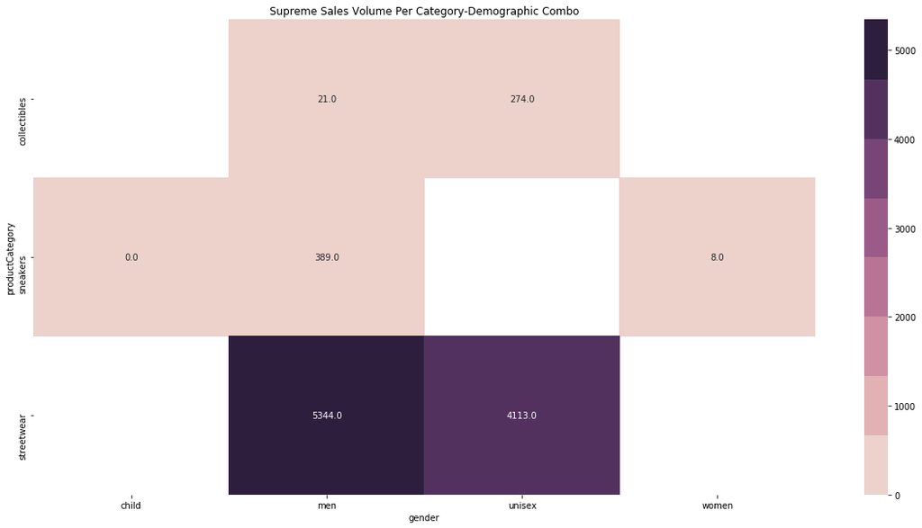

```python
category_demographic_volume_heatmap(supreme_df, "Supreme")
```

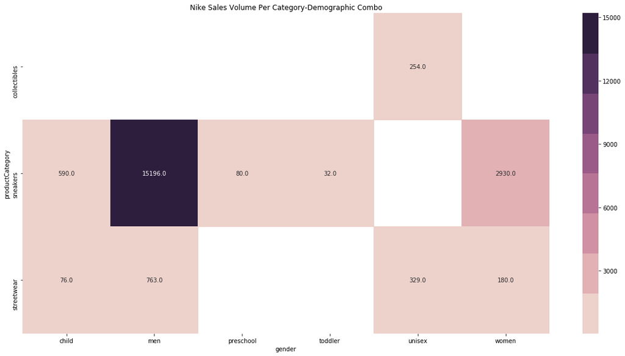

```python
category_demographic_volume_heatmap(nike_df, "Nike")
```

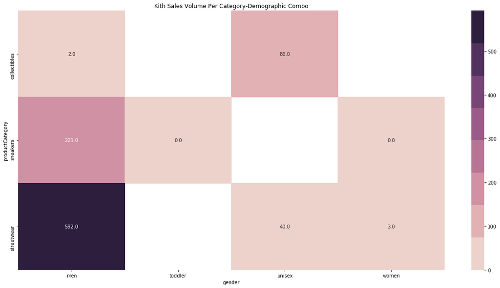

```python
category_demographic_volume_heatmap(kith_df, "Kith")
```

These results fall in line with what we expect.

**Supreme**

For Supreme, the highest volume of products is the men's streetwear category. Given that Supreme is a clothing brand, this makes sense.

**Nike**

For Nike, the highest volume of products is the men's sneaker category. This also makes sense. Nike consistently releases new variants and colorways of their sneakers. For example, Nike often sells new versions of the Air Jordan sneaker, which can be seen [here.](https://sneakernews.com/air-jordan-release-dates/)

**Kith**

Finally, for Kith, the highest volume of products is men's streetwear. This is expected considering Kith's main products are streetwear.

#### **Resale Margin & Demographic**

```python
def category_demographic_resale_heatmap(df, company):
  plt.figure(figsize=(20,10))
  df_pivoted = df.pivot_table(index='productCategory', columns='gender', values="resell_margin", aggfunc=np.mean)
  sns.heatmap(df_pivoted, annot=True, fmt=".1f", cmap=sns.cubehelix_palette(8, start=2, rot=0, dark=0, light=.95, reverse=False)).set_title(f'{company} Resale Margin Per Category-Demographic Combo')
```

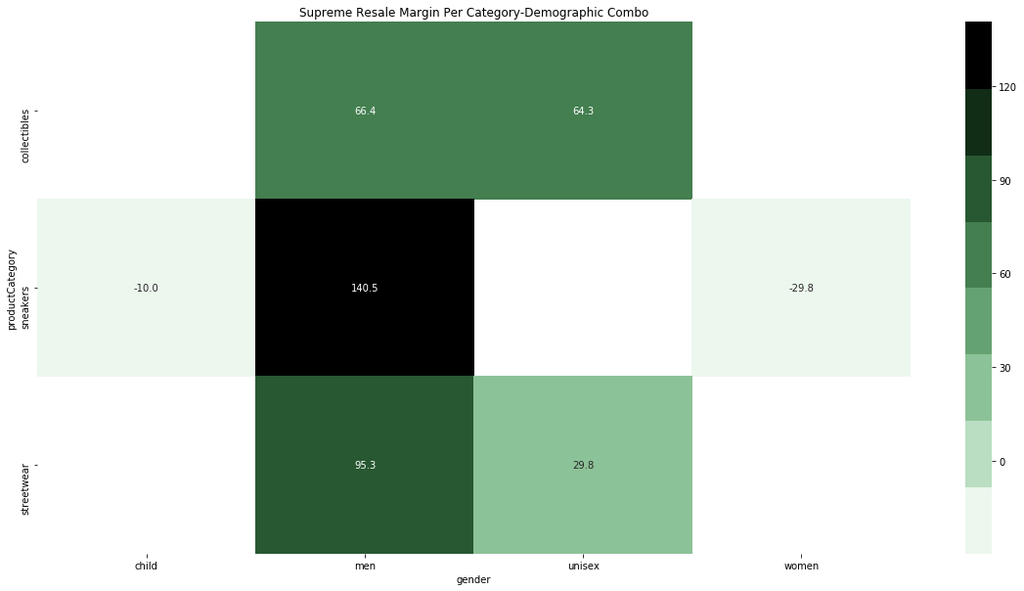

```python
category_demographic_resale_heatmap(supreme_df, "Supreme")
```

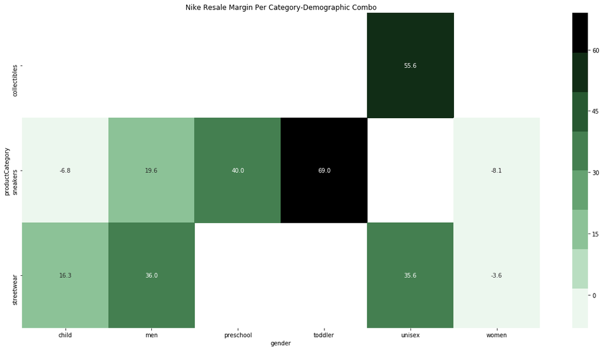

```python
category_demographic_resale_heatmap(nike_df, "Nike")
```

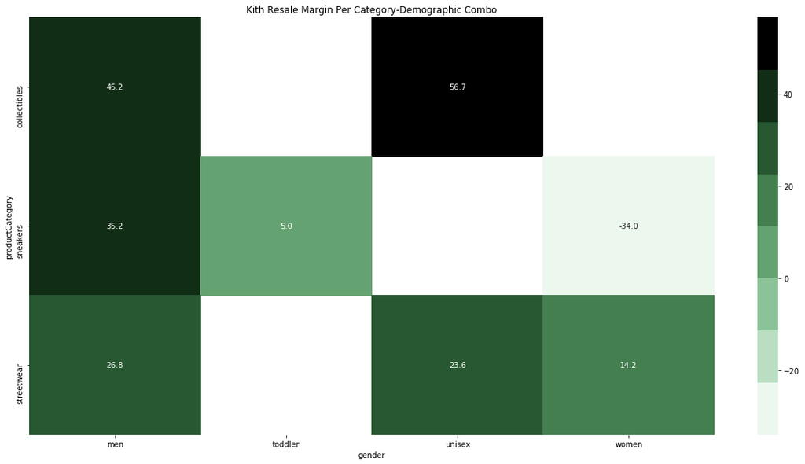

```python
category_demographic_resale_heatmap(kith_df, "Kith")
```

The results from these graphs are actually pretty interesting.

**Supreme**

Despite Supreme being a streetwear brand, the highest resell margins come from men's sneakers. Supreme sometimes does do sneaker collaborations with other companies, such as the [Air More Uptempo Supreme "Suptempo" Gold](https://stockx.com/nike-air-more-uptempo-supreme-gold), which could explain this high resell margin.

**Nike**

The highest margin to be made with Nike products is toddler sneakers. One reason for this could be that there is often much less toddler stock. With less supply, the resell prices would jump up, following the principles of supply and demand.

**Kith**

For Kith, the highest profit margins come from collectibles. Given their rarity in how often Kith releases these products, and the often high starting price, this makes sense.

This brings us into the next point. Up until now, we have only been looking at raw profit margin. However, we should also be considering the price premium of the product, which is the profit margin relative to the retail price of the product.

## **Do Higher Retail Prices Equate To Higher Resale Premuims?**

It is common for [profit margins](https://en.wikipedia.org/wiki/Profit_margin) to increase the more expensive a product is. This is because the more it costs to produce a product, the more risk the creater takes on before sale.

So is this the case with these scare products in the streetwear market? We predict that there may be some counterintuitive results because much of the margins are artifically manipulated.

A [commodity](https://en.wikipedia.org/wiki/Commodity) has no hype and will likely have clear margin increases as the cost of unit production increases. On the other hand, in the space we are looking at, collectibles as cheap as \$50 having resales of \$800 (\$750 gross profit) and sneakers that cost $220 can resale at \$300 (\$80, a lower gross profit).

Let's see:

```python
def retail_price_and_premium_jointplot(df, por_cap, rp_cap, company):
  g = sns.jointplot(
      "retailPrice",
      "percent_over_retail",
      data=df[(df['percent_over_retail'] < por_cap) & (df['retailPrice'] < rp_cap)],
      kind="hex",
      space=0,
  )
  g.fig.suptitle(f'{company} Retail Price & Retail Premium Distribution')
```

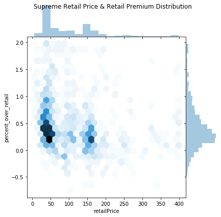

```python
retail_price_and_premium_jointplot(supreme_df, 2, 400, "Supreme")
```

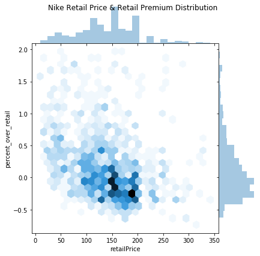

```python
retail_price_and_premium_jointplot(nike_df, 2, 350, "Nike")
```

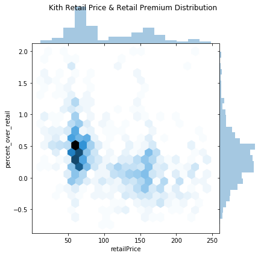

```python
retail_price_and_premium_jointplot(kith_df, 2, 250, "Kith")
```

For Supreme, it seems like sales are centered over relatively cheaper products (= \$50) with relatively lower premiums of around = 20% to = 50%.

For Nike, though, we something very interesting. Sales volume is concentrated around products between \$150 - \$200, which makes sense as this is the range for which their sneakers are priced. However, what we see is that most Nike products are being sold under retail.

For Kith, we see something very similar to Supreme, the product's retail prices are focused on reliatvely cheaper products (= \$50) with price premiums of = 15% to = 50%.

**Now what?**

Now that we have explored correlations between features we could extract from the StockX data, let's go further.

Can we find a way to look at these relationships and establish connections? This may or may not be possible with the data that we have collected.

Can we build a model matching features we have analyzed, such as category, color, demographic, and retail price to the price premium of a product. What this would effectively do is build us a model for predicting a product's "hype."

## **Machine Learning**

Before we start doing some linear regressions and ML, we are going to want to organize the data just a bit more. We have 3 categorical features that we want to convert to numerical.

```python
categories = ['sneakers', 'streetwear', 'collectibles']
genders = ['men', 'women', 'child', 'preschool', 'toddler', 'unisex']
colors = [
  'black', 'white', 'blue', 'red', 'gold', 'orange',
  'navy', 'yellow', 'gray', 'silver',
  'purple', 'green', 'brown', 'pink'
]

# Convert the categorical variables to numerical
def convert_categorical_data(df):
  features = ['retailPrice']

  for category in categories:
    col_name = 'is_' + category
    df[col_name] = df.apply(lambda row: 1 if row['productCategory'] == category else 0, axis=1)
    features.append(col_name)

  for gender in genders:
    col_name = 'is_' + gender
    df[col_name] = df.apply(lambda row: 1 if row['gender'] == gender else 0, axis=1)
    features.append(col_name)

  for color in colors:
    col_name = 'is_' + color
    df[col_name] = df.apply(lambda row: 1 if row['color'] == color else 0, axis=1)
    features.append(col_name)

  return (df, features)

def run_regression(df):
  # Prepare the dataframe
  df_converted, features = convert_categorical_data(df)

  # Extract the feature matrix
  feature_matrix = df_converted[features]

  # Extract the target vector we will predict against
  target_vector = df_converted[['percent_over_retail']]

  # Split test data
  X_train, X_test, y_train, y_test = train_test_split(feature_matrix, target_vector, test_size=0.2)

  # Run regression
  linear_model = LinearRegression()
  model = linear_model.fit(X_train, y_train)
  coeff_of_det = model.score(X_test, y_test)

  predictions = linear_model.predict(X_test)

  return (model.coef_, coeff_of_det, predictions, y_test)

# Run the regression and extract coefficients & a prediction vector
coefficients, coeff_of_det, predictions, y_test = run_regression(supreme_df)
print(f"Coefficients: {coefficients}")
print(f"Coefficient of determination: {coeff_of_det}")
```

```
Coefficients: [[-1.76079407e-03  1.32189663e-01 -2.52815018e-01  1.20625356e-01
   6.54941589e-01 -1.89073618e-01 -8.49635155e-01 -8.32667268e-17
  -2.08166817e-17  3.83767183e-01 -1.64270324e-01  2.49900806e-01
   1.42338144e-01 -2.05923375e-01 -5.39010536e-02 -7.92717204e-01
  -2.93586777e-01  1.23705405e-01  0.00000000e+00  9.39230306e-01
  -1.86582265e-01 -4.77138418e-01  3.28872048e-01  3.90072708e-01]]
Coefficient of determination: 0.060537855335975665
```

So after running our linear model we see that our coefficient of determination hovers around 0 (ranging from -1% to 15%).

The [coefficient of determination](https://en.wikipedia.org/wiki/Coefficient_of_determination) (denoted R² or r²) is the proportion of the variance in the dependent variable (retail premium percent) that is explained by the independent variables (our features).

An R² value of 0 means that the retail premium cannot be predicted from our feature set.

Let's see what the actual premiums vs the premiums our model predicts

Let's see what this actually looks like, plotting actual price premiums over what the model predicts:

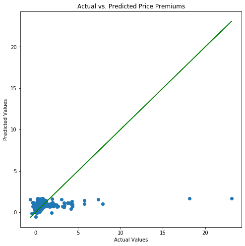

```python
def plot_performance(y_test, predictions):
  plt.figure(figsize=(8,8))
  plt.title("Actual vs. Predicted Price Premiums")

  plt.scatter(y_test, predictions) # Actual vs predictions
  plt.plot(y_test, y_test, color="g") # If the model is perfect it will adhere to y = x

  plt.xlabel("Actual Values")
  plt.ylabel("Predicted Values")

  plt.show()

plot_performance(y_test, predictions)
```

And here we can visually see that our model is weak and did not predict the test price premiums well at all.

Let's try a different feature set.

```python
def run_regression_2(df):
  feature_matrix = df[['retailPrice']]
  target_vector = df[['percent_over_retail']]

  # Split test data
  X_train, X_test, y_train, y_test = train_test_split(feature_matrix, target_vector, test_size=0.2)

  # Run regression
  linear_model = LinearRegression()
  model = linear_model.fit(X_train, y_train)
  coeff_of_det = model.score(X_test, y_test)

  predictions = linear_model.predict(X_test)

  return (model.coef_, coeff_of_det, predictions, y_test)

coefficients, coeff_of_det, predictions, y_test = run_regression_2(supreme_df)
print(f"Coefficients: {coefficients}")
print(f"Coefficient of determination: {coeff_of_det}")
```

```
Coefficients: [[-0.00152099]]
Coefficient of determination: -0.0039913123759400815
```

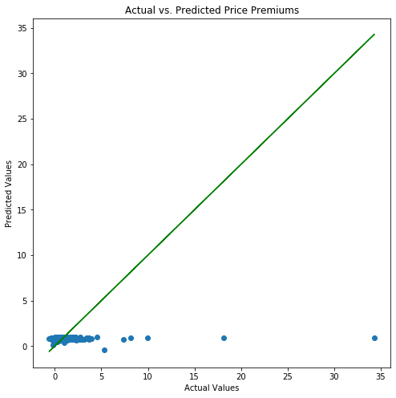

```python
plot_performance(y_test, predictions)
```

And again, we see that this model (only using retail price) is not predicting resale retail premium very well.

This appears dismal, but there may be hope.

Let's plot the retail price versus resale premium percent to see if this data is actually linear.

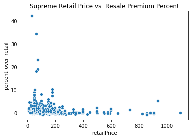

```python
sns.scatterplot(x="retailPrice", y="percent_over_retail", data=supreme_df).set_title("Supreme Retail Price vs. Resale Premium Percent")
```

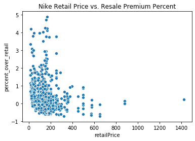

```python
sns.scatterplot(x="retailPrice", y="percent_over_retail", data=nike_df).set_title("Nike Retail Price vs. Resale Premium Percent")
```

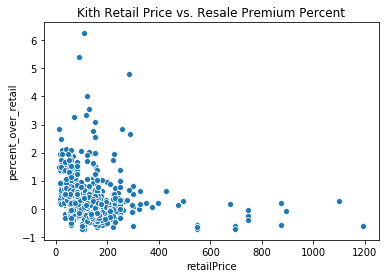

```python
sns.scatterplot(x="retailPrice", y="percent_over_retail", data=kith_df).set_title("Kith Retail Price vs. Resale Premium Percent")
```

**And this is interesting.** It looks like this data may not be linear after all.

It looks like retail price and resale premium percentage have an [inverse relationship](https://en.wikipedia.org/wiki/Negative_relationship) that looks nearly like the prototypical [multiplicative inverse function](https://en.wikipedia.org/wiki/Multiplicative_inverse) 1/x.

So instead of trying to create a linear regression, let's create a non-linear model instead. We must be careful to avoid underfitting and overfitting our data, so we must ensure that we pick the appropriate degree of polynomial approximation.

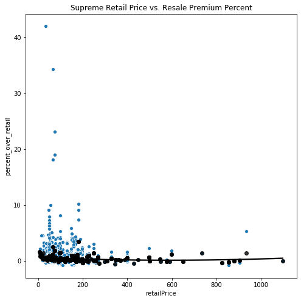

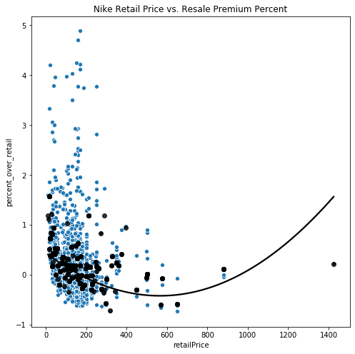

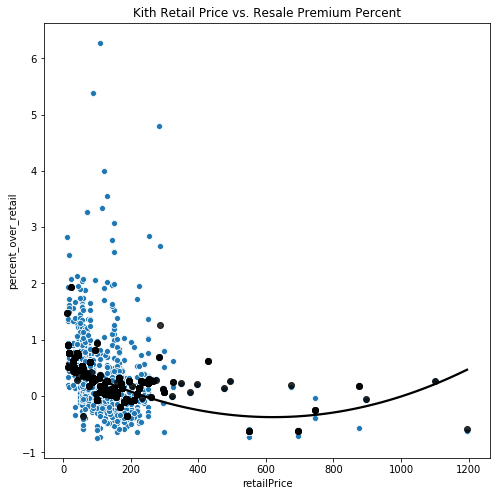

```python
def poly_model(df, company):
  colors = ['black', 'teal', 'yellowgreen', 'gold']

  df_sorted = df.sort_values(by=['retailPrice'])

  feature_matrix = df_sorted[['retailPrice']]
  target_vector = df_sorted[['percent_over_retail']]

  for index, degree in enumerate([2]):
    # Create model
    model = SVR(C=1, degree=degree, epsilon=.02)
    model.fit(feature_matrix, target_vector)
    y_predicted = model.predict(feature_matrix)

    merged_dataset = feature_matrix
    merged_dataset['percent_over_retail'] = y_predicted

    # Plot data points
    plt.figure(figsize=(8,8))
    sns.scatterplot(x="retailPrice", y="percent_over_retail", data=df).set_title(f"{company} Retail Price vs. Resale Premium Percent")

    # Draw Regression
    sns.regplot(x="retailPrice", y="percent_over_retail", data=merged_dataset, order=degree, ci=None, truncate=True, color='Black')

poly_model(supreme_df, "Supreme")
poly_model(nike_df, "Nike")
poly_model(kith_df, "Kith")
```

[figure not shown]

## **Where Should These Brands Focus Their 2020 Efforts?**

First, let's again recognize that the depth of the data that we collected was fairly shallow. StockX has 10's of thousands of products, which we were not able to fully scrape.

Considering that, for Nike and Kith, there is definitely a negative relationship between retail price and the price premium. What we learn from this is that products that are relatively cheaper correlate with higher resell margins. However, in the larger picture we previously noted that retail price has to be balanced with sales volume, as we saw with the Nike collectibles (this also happens with Kith collectibles).

On the other hand, it seems as though there was a relatively constant relationship with Supreme, indicating the power that the brand has. Anything that Supreme sells will be bought up and sold at a higher price.

Although we were able to identify key trends relating to sales volumes, the best colors, and price premiums, etc, we learned that there are too many features to estimate a product's "hype." In reality, fashion, what looks good to certain people, and how people view brands is subjective. To make confident decisions we would need more exhaustive data (especially historical).

#### **Further Experimentation**

If we were to take this investigation further, we would want historical data on all of StockX's products so we could look at seasonal trends. Having this data, we could also observe how partnerships and collaborations affect an item's popularity, such as the Nike X OFF-WHITE [collaboration](https://solecollector.com/news/2019/12/virgil-abloh-off-white-nike-dunk-low-leather-university-gold-midnight-navy-white-university-red-wolf-grey-white-pine-green-release-date).

Finally, if we had more time, we would have wanted to get better color analysis of products and could have potentially used some 3rd party services to detect colors in images.